# Class 1: Fundamentals of probability and statistical inference

Bernhard Angele  
Oct 1st, 2015

### Advanced Statistics

### What did/will we do on Thursday?

- We did/will do a quick overview of probability as you will have encountered it in school
- We will have generated some data using dice and coins.
- We will use those data to explore descriptive statistics
  - Measures of central tendency such as *mean* and *median*
  - Measures of disperson or variability such as variance and standard deviation

### What is advanced about these statistics?

- Goal is for you to understand the principles, not just the steps.
- Simulation approach:
  - If you don't know how something about a statistical test, simulate it!
  - Example questions you might ask:
  - What is the power of this test?
  - What happens if I violate the normality assumption for an ANOVA?
  - What happens if I don't correct for multiple comparisons?

### How do I run simulations?

- Not very easy in SPSS
- But Excel can help (to some degree..)
- For more detailed simulations, you'll have to use a programming language such as R, Python, C++, etc.

### Introduction

- Let's start nice and easy. I brought some dice to class. This was my task:
  - There are dice in 9 different colours
  - I want you to find out if the orange dice are loaded (i.e. if they have the tendency to end up on certain sides more than on others)
- How should you go about this?

### Maths basics: Summation

- The summation operator \( \Sigma \): \[ x_1 + x_2 + x_3 + x_4 + x_5 = \sum\limits_{i=1}^5{x_i} \]
- This means: beginning with \( i=1 \) and ending with \( i=5 \) sum over the variables \( x_i \).
  - This can save a lot of space if you are summing over lots of variables
  - \( i \) is called the *index* over which you are summing, and \( 1 \) and \( 5 \) are the limits.
- If the limits are clear from the context, you can also write this as

\[ \sum\limits_{i}{x_i} \]

### Maths basics: Summation

- The summation operator \( \Sigma \): \[ x_1 + x_2 + x_3 + x_4 + x_5 = \sum\limits_{i=1}^5{x_i} \]
- This means: beginning with \( i=1 \) and ending with \( i=5 \) sum over the variables \( x_i \).
  - This can save a lot of space if you are summing over lots of variables
  - \( i \) is called the *index* over which you are summing, and \( 1 \) and \( 5 \) are the limits.
- If the limits are clear from the context, you can also write this as

\[ \sum\limits_{i}{x_i} \]

### Maths basics: Summation (2)

- You can have multiple multiple indeces and sum over them (e.g. if you have multiple people in multiple groups, which is something that happens in Psychology *ALL THE TIME*). For example:

Group 1 (females): \( x_{11}, x_{12}, x_{13}, x_{14} \)

Group 2 (males): \( x_{21}, x_{22}, x_{23}, x_{24} \)

### Maths basics: Multiplication

- The product symbol \( \Pi \):
- Works just like the summation symbol: \[ x_1 \cdot x_2 \cdot x_3 \cdot x_4 \cdot x_5 = \prod\limits_{i=1}^5{x_i} \]
- This means: beginning with \( i=1 \) and ending with \( i=5 \) calculate the product over the variables \( x_i \).

\[ \begin{aligned} \prod\limits_{m=1}^{2}\prod\limits_{x=1}^{4}{x_{mi}} = x_{11}\cdot x_{12}\cdot x_{13}\cdot x_{14} \\ \cdot x_{21} \cdot x_{22} \cdot x_{23} \cdot x_{24} \end{aligned} \]

### Maths basics: Probability

- Basic rules:
  - All probabilities are between 0 and 1: \( P(A)\in[0,1] \)
  - The complementary probability of an event (i.e. the probability that an event will NOT happen) is 1-the probability of the event: \( P(A^c)=1-P(A) \)
  - A probability can be interpreted as the number of outcomes that form an event (e.g. the outcome “Heads” when flipping a coin) over the total number of outcomes (e.g. “Heads” and “Tails”) \[ p(A) = \frac{n_A}{n} \]
  - But note that a probability of .5 (e.g. for getting “Heads”“ on a coin flip) doesn't mean that you will get "Heads”“ on exactly 50% of coin flips.

### Maths basics: Probability (2)

- Basic rules:
  - What is the probability that Event A and Event B will happen together? \[ \begin{align} P(A\cap B) & = P(A|B)P(B) = P(B|A)P(A)\\ P(A\cap B) & = P(A)P(B) \qquad\\&\mbox{if A and B are independent}\\ \end{align} \]
  - What is the probability that either Event A OR Event B will happen?: \[ \begin{align} P(A\cup B) & = P(A)+P(B)-P(A\cap B) \\ P(A\cup B) & = P(A)+P(B) \\\qquad&\mbox{if A and B are mutually exclusive} \\ \end{align} \]

### Maths basics: Conditional probability

- What is the probability of Event A *GIVEN THAT* Event B happened?
  - Divide the number of outcomes where A and B happen together by the number of all outcomes where B happens (regardless of whether A happened, too).
  - If we divide both nominator and denominator by \( n \), we can convert this into probabilities: \[ P(A \mid B) = \frac{n_{AB}}{n_B} = \frac{n_{AB}/n}{n_B/n} = \frac{P(A \cap B)}{P(B)} \]
- Now plug in our definition of joint probability (see last slide): \[ P(A \mid B) = \frac{P(A \cap B)}{P(B)} = \frac{P(B|A)P(A)}{P(B)} \]
- This is known as *Bayes' theorem*. Keep it in mind for later!

### Back to our dice problem

- IN THEORY, each of our dice roll outcomes has the same probability: \[ \begin{aligned} p(1) = \frac{n_1}{n_{total}} &= \frac{1}{6}, p(2) = \frac{n_2}{n_{total}} &= \frac{1}{6}\\ p(3) = \frac{n_3}{n_{total}} &= \frac{1}{6}, p(4) = \frac{n_4}{n_{total}} &= \frac{1}{6}\\ p(5) = \frac{n_5}{n_{total}} &= \frac{1}{6}, p(6) = \frac{n_6}{n_{total}} &= \frac{1}{6} \end{aligned} \]
- But how can we test whether that is actually true?
- We need some way to compare the data to the actual probability distribution

### Statistics basics: Random variables

- We need to consider our sample as a random variable
- What is a random variable?
  - A random variable is a function that assigns a number to each possible outcome of our experiment (the dice roll)
- The outcome of a single dice roll can be described by a very obvious function: just assign the numbers from 1 to 6
- The outcome of *multiple* dice rolls is little trickier
- Regardless of which one we choose, we can then come up with a *theoretical* probability distribution for the random variable.

### Statistics basics: Random variables (formal definition!)

- Warning: Some mathematical notation follows.
- A random variable \( X \) is a function \( X : O \rightarrow \mathbb{R} \) that associates to each outcome \( \omega \in O \) exactly one number \( X(\omega) = x \).
  - Note: \( \mathbb{R} \) = real numbers
- \( O_X \) is all the \( x \)'s (all the possible values of X, the support of X). i.e., \( x \in O_X \).
- Good example: number of coin tosses till you get Heads (H) for the first time
  - \( X: \omega \rightarrow x \)
  - \( \omega \): H, TH, TTH,\( \dots \) (infinite)
  - \( x=0,1,2,\dots; x \in O_X \)

### Random variables (2)

Every discrete random variable X has associated with it a **probability mass function**, also called *distribution function*. \[ \begin{equation} p_X : S_X \rightarrow [0, 1] \end{equation} \] defined by \[ \begin{equation} p_X(x) = P(X(\omega) = x), x \in S_X \end{equation} \]

- Back to the example: number of coin tosses till H
  - \( X: \omega \rightarrow x \)
  - \( \omega \): H, TH, TTH,\( \dots \) (infinite)
  - \( x=0,1,2,\dots; x \in S_X \)
  - \( p_X = .5, .25, .125,\dots \)

### What is a probability distribution?

From Wikipedia: In probability and statistics, a probability distribution assigns a probability to each measurable subset of the possible outcomes of a random experiment, survey, or procedure of statistical inference. Here's an example of a discrete probability distribution, the distribution of the *sum of two dice rolls*:

[figure not shown]

### Discrete probability distribution

[figure not shown]

Every possible outcome (sum of the numbers rolled on two dice) is assigned a corresponding probability. This is called a *probability mass function*.

Important: all values sum to 1.

### From discrete to continuous

- Let's look at the probability distributions we get from rolling one, two, three etc. dice and summing up the results.
- We'll start with rolling one die.

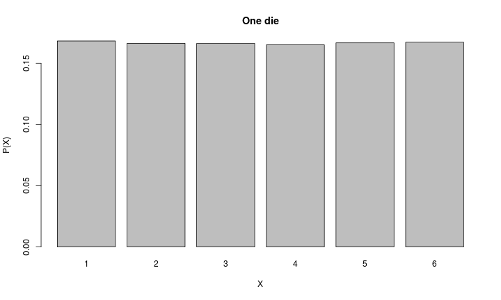

### Two dice

- This is the same as the image from Wikipedia, just less nicely illustrated.

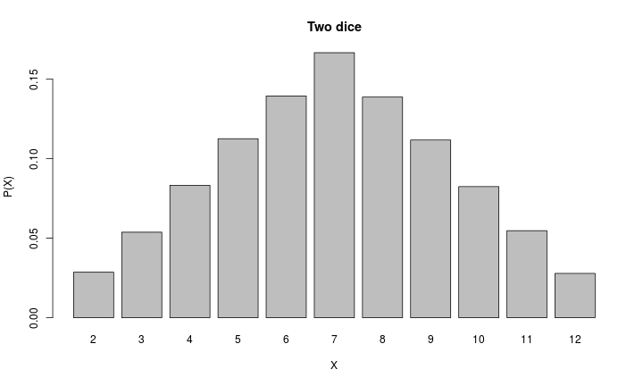

### Three dice

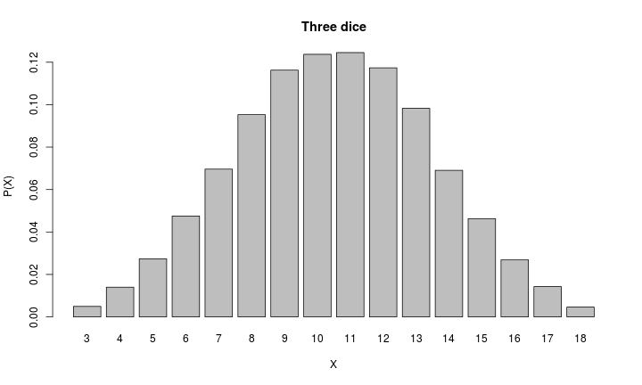

### Four dice

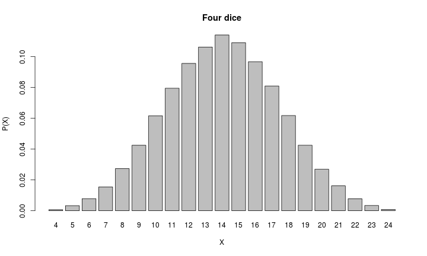

### Ten dice

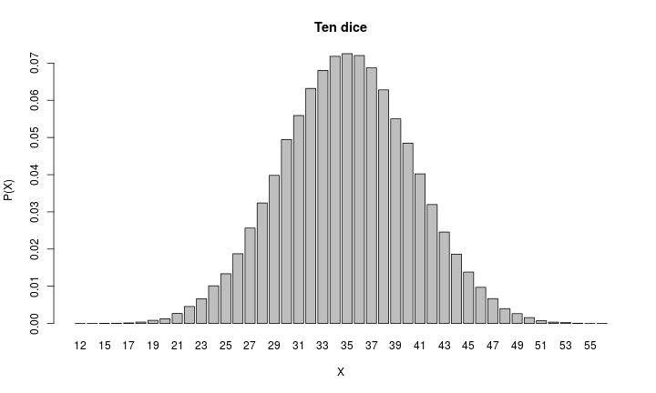

### 100 dice

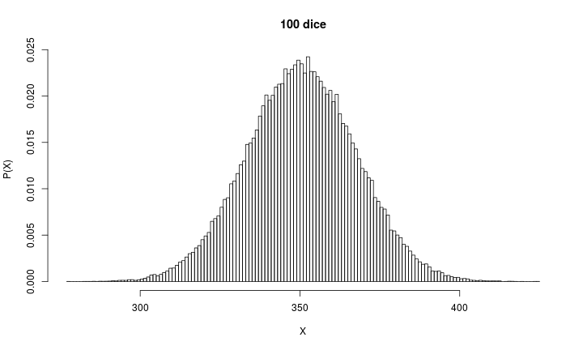

### Continuous probability distribution

Here, the outcomes are continuous, so it doesn't make sense to ask about the probability of any point on the x-axis.

- What is the probability of x = 1?
  - What do you mean by “1”? Does 1.00001 still qualify as 1?
- It makes more sense to ask these questions about intervals.
- Important: the total area under the curve is 1.

### Normal probability density function (PDF)

\[ f(x,\mu,\sigma) = \frac{1}{\sigma \sqrt{2 \pi}} e^{-((x - \mu)^2/2 \sigma^2)} \]

With \( x \) = value, \( \mu \) = mean, and \( \sigma \) = standard deviation

### Defining the normal PDF by hand (just in case you wanted to make sure)

\[ f(x,\mu,\sigma) = \frac{1}{\sigma \sqrt{2 \pi}} e^{-((x - \mu)^2/2 \sigma^2)} \]

```r
dnorm_manual <- function(x, mu = 0, sigma = 1) {1/(sigma*sqrt(2*pi)) * exp(-((x-mu)^2/2*sigma^2))}
plot(function(x) dnorm_manual(x), -3, 3,
main = "Normal density",ylim=c(0,.4),
ylab="density",xlab="X")
```

[output not shown]

### Asking reasonable questions about continuous distributions

- What's the probability of x being between 0 and 1?

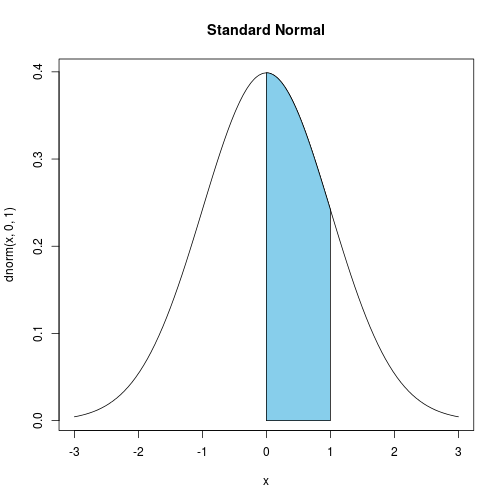

- How do we do this?
- We could integrate!
  - But there's a more convenient way in R.

### Using `pnorm`

- `pnorm(q)` gives you the probability of `x < q` (in the standard normal distribution)

```r
pnorm(1)
```

```
[1] 0.8413447
```

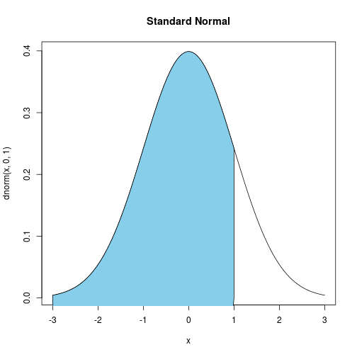

- `pnorm(1)` is not quite what we wanted yet.

### Using `pnorm` (2)

- What about `pnorm(0)`?

```r
pnorm(0)
```

```
[1] 0.5
```

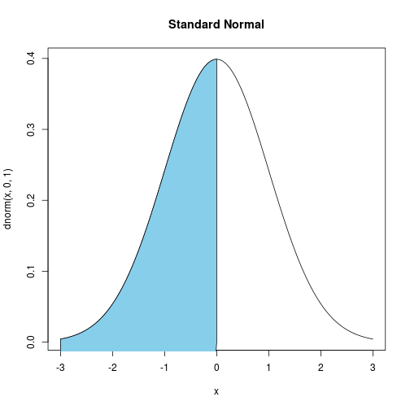

Well, look at that!

### Finally getting our area under the curve

- I hope you can guess how to do it now:

```r
pnorm(1)-pnorm(0)
```

```
[1] 0.3413447
```

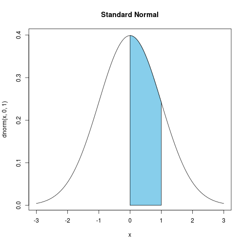

- Success!

### Things you can do with this knowledge

- Say I'm looking at random numbers from a standard normal distribution:

```r
rnorm(5)
```

```
[1] -0.67877317 -0.06830544 -0.23724900 -0.30045108  0.06709089
```

- and I see that one of them is 4.
  - That seems very unusual
  - Just how unusual?
  - What's the probability of getting a value of 4 when sampling from a standard normal distribution (mean = 0, sd = 1)?

### Just how unusual is a value of 4?

- Remember, when you have a continuous distribution, you can't think about point values (e.g. 5). Rather, what you want to know is:
  - What is the probability of getting a value of 4 *or greater*?

```r
print(pnorm(4), digits = 5)
```

```
[1] 0.99997
```

- Is that the probability? No, that's the probability of getting a value of 4 *or less*
- Just get the inverse probability:

```r
1 - pnorm(4)
```

```
[1] 3.167124e-05
```

### Why do we care about the normal distribution?

- Central limit theorem (CLT)

> When sampling from a population that has a mean, provided the sample size is large enough, the sampling distribution of the sample mean will be close to normal regardless of the shape of the population distribution

Let's see if that's actually true by running some simulations!

### Maths basics: Expected values

- Random variables have expected values
- For discrete random variables, the expected value is the outcome value multiplied by the probability of the outcome: \[ E(X) = \sum\limits_{i=1}^k p(x_i)\cdot x_i \]
  - where \( E(X) \) is the expected value of a discrete random variable \( X \) with the outcomes \( (x_1 \dots x_k) \) and the associated probabilities \( (p(x_1)\dots p(x_k)) \)

### Maths basics: Expected values (2)

- For example, the expected value of rolling a six-sided die is: \[ \begin{aligned} E(X) &= \sum\limits_{i=1}^{6} p(x_i) \cdot x_i \\ &= x_1 \cdot p(x_1) + x_2 \cdot p(x_2) + x_3 \cdot p(x_3) + x_4 \cdot p(x_4) \\ &+ x_5 \cdot p(x_5) + x_6 \cdot p(x_6) \\ &= 1 \cdot \frac{1}{6} + 2 \cdot \frac{1}{6} + 3 \cdot \frac{1}{6} + 4 \cdot \frac{1}{6} \\ &+ 5 \cdot \frac{1}{6} + 6 \cdot \frac{1}{6} \\ &= \frac{21}{6} = 3.5 \end{aligned} \]

### Maths basics: Expected values (3)

- What is the expected value of rolling two dice and adding the spots?
- What is the expected value of rolling two dice and multiplying the number of spots?
- What is the expected value of an IQ test result?
- Imagine you and your friend both take IQ tests. What is the expected value of the differences between your scores (assuming that you both come from the general population)?
  - Don't know? Well, stay tuned. This will require some maths, though.

### Maths basics: Computing expected values

- The expected value of a random variable is often also called \( \mu \): \[ E(X) = \mu \]
  - \( \mu \) is also called the distribution *mean*
- What if the expected value is constant across all the possible outcomes?
  - e.g what is the expected value of a die with 1 on all sides?
    - 1, of course!
- More general:
  - if the value is the same across all outcomes, we can call it a constant
  - e.g. if \( x_1 = x_2 = x_3 = \dots = x_i = 1 \)
    - then \( E(X) = E(1) = 1 \)

### Maths basics: Computing expected values (2)

Even more general: If a is a constant, then \( E(a) = a \)

- If \( X \) is a random variable and \( a \) is a constant, what is the expected value of \( a \cdot X \)? \[ E(a\cdot X) = a \cdot E(X) \]
- For example, if the expected value of rolling a 6-sided die is 3.5, what is the expected value of rolling a 6-sided die and then multiplying the number of spots by 3? \[ E(3\cdot X) = 3\cdot E(X) = 3\cdot 3.5 = 10.5 \]
- Try it if you don't believe me!

### Maths basics: Computing expected values (3)

- If \( X \) is a random variable and \( a \) is a constant, what is the expected value of \( a + X \)? \[ E(a + X) = a + E(X) \]
- For example, if the expected value of rolling a 6-sided die is 3.5, what is the expected value of rolling a 6-sided die and then adding 3 to the number of spots? \[ E(3 + X) = 3 + E(X) = 3 + 3.5 = 6.5 \]
- Try it if you still don't believe me!

### Maths basics: Computing expected values (4)

- If \( X \) is a random variable and \( Y \) is a random variable, what is the expected value of \( X + Y \)? \[ E(X + Y) = E(X) + E(Y) \]
- For example, if the expected value of rolling two 6-sided dice and adding the two results? \[ E(X + Y) = E(X) + E(Y)= 3.5 + 3.5 = 7 \]
- Try it if you still don't believe me!

### Maths basics: Computing expected values (5)

- If \( X \) is a random variable and \( Y \) is a random variable, what is the expected value of \( X \cdot Y \)? \[ E(X \cdot Y) = E(X) \cdot E(Y) \]
- But *ONLY* if \( X \) and \( Y \) are *INDEPENDENT*
- For example, if the expected value of rolling two 6-sided dice and multiplying the two results? \[ E(X + Y) = E(X) \cdot E(Y)= 3.5 \cdot 3.5 = 12.25 \]
- Try it if you still don't believe me!

### The expected value of the sample mean

- If \( X \) is a random variable, and we take a sample of size \( n \) from \( X \), what is the expected value of the mean of that sample?
- Remember, this is how you compute the sample mean: \[ \bar{x} = \frac{\sum\limits_{i=1}^{n}}{n} \]
- The expected value of the sample mean is: \[ \begin{aligned} E(\bar{X}) &= E\Bigg(\frac{\sum\limits_{i=1}^{n}}{n}\Bigg)\\ &= \frac{1}{n}\cdot\big(E\sum\limits_{i=1}^n{X_i}\big) \end{aligned} \]

### The expected value of the sample mean (2)

\[ \begin{aligned} &= \frac{1}{n}\cdot\big(E\sum\limits_{i=1}^n{X_i}\big) \text{ (since } E(a\cdot X) = a \cdot E(X)\text{)} \\ &= \frac{1}{n}\cdot\sum\limits_{i=1}^n{E(X_i)} \text{ (since } E(X+Y) = E(X) + E(Y)\text{)} \\ &= \frac{1}{n}\cdot\sum\limits_{i=1}^n{\mu_x} \text{ (since } E(X) = \mu \text{)} \\ &= \frac{1}{n}\cdot n \cdot\mu_x = \mu_x \end{aligned} \]

### The expected value of the sample mean (3)

- We just found that the expected value of the sample mean \( E(\bar{X}) \) is identical to the population mean \( \mu_x \), *regardless of the sample size*.
- We can say that the sample mean \( \overline{X} \) is an *unbiased estimator* of the population mean \( \mu \)
- No matter what we do and what crazy population we're taking samples of, the sample means will always be distributed around the true population mean.
  - *Isn't that cool?*
  - I know what you're thinking right now, but this is *actually* cool. Just think about it: If you want to know the true population mean of any population, all you have to do is take enough samples.

### The expected value of the sample variance

- OK, now we want to know how the variance of your samples (\( s^2 \)) is related to the population variance \( \sigma^2 \).
- Remember that the variance of a sample is \[ s^2 = \frac{\sum\limits_{i=1}^{n}(x_i - \bar{x})^2}{n} \]
- We can rewrite this as: \[ \begin{aligned} s^2 &= \frac{\sum\limits_{i=1}^{n}(x_i - \bar{x})^2}{n} = \frac{\sum\limits_{i=1}^{n}(x_i^2 - 2\cdot x_i + \bar{x})^{2}}{n}\\ &=\frac{\sum\limits_{i=1}^{n}x_i^2 - 2\cdot \bar{x} \cdot\sum\limits_{i=1}^{n}x_i + \bar{x}^{2}}{n} \end{aligned} \]

### The expected value of the sample variance (2)

- Further rewriting: Since \( \sum\limits_{i=1}^{n} x_i = n \cdot \bar{x} \) : \[ \begin{aligned} s^2 &=\frac{\sum\limits_{i=1}^{n}x_i^2 - 2\cdot \bar{x} \cdot\sum\limits_{i=1}^{n}x_i + \bar{x}^{2}}{n}\\ &= \frac{\sum\limits_{i=1}^{n}x_i^2 - 2\cdot \bar{x} \cdot n \cdot \bar{x} + \bar{x}^{2}}{n}\\ &= \frac{\sum\limits_{i=1}^{n}x_i^2 - n\cdot \bar{x}^2}{n} = \frac{\sum\limits_{i=1}^{n}x_i^2}{n} - \bar{x}^2 \end{aligned} \]

### The expected value of the sample variance (3)

- Now we can calculate the expected value of \( s^2 \): \[ \begin{aligned} E(S^2) &= E\Bigg(\frac{\sum\limits_{i=1}^{n}X_i^2}{n} - \bar{X}^2\Bigg) \\ &= E\Bigg(\frac{\sum\limits_{i=1}^{n}X_i^2}{n}\Bigg) - E(\bar{X}^2) \\ &= \frac{\sum\limits_{i=1}^{n}E(X_i^2)}{n} - E(\bar{X}^2) = \frac{n\cdot E(X_i^2)}{n}-E(\bar{X}^2) \end{aligned} \]

### The expected value of the sample variance (4)

- And \( \frac{n\cdot E(X_i^2)}{n}-E(\bar{X}^2) \) of course simplifies to \( E(X_i^2)-E(\bar{X}^2) \)
- So, now we have to figure out what \( E(X_i^2) \) and \( E(\bar{X}^2) \) are.
- The easiest way to do this is to start with the population variance \( \sigma^2 \) and the variance of the sample means \( \sigma_{\bar{x}}^2 \)

### The expected value of the sample variance (5)

- We can define the population variance as \( \sigma^2 = E(X_i - \mu)^2 \), the expected value of the squared deviations of \( X \) from the population mean \( \mu \)
- Let's rewrite this: \[ \begin{aligned} \sigma^2 &= E(X_i - \mu)^2 = E(X_i^2 - 2X_i\mu + \mu^2) \\ &= E(X_i^2) - E(2X_i\mu) + E(\mu^2)\\ &= E(X_i^2) - 2\mu E(X_i) + \mu^2 \end{aligned} \] since \( \mu \) is a constant (and \( \mu^2 \) is too, of course).

### The expected value of the sample variance (6)

Continuing from previous slide:

- We already determined that \( \mu = E(X) \), so: \[ \begin{aligned} \sigma^2 &= E(X_i^2) - 2\mu E(X_i) + \mu^2 \\ &= E(X_i^2) - 2\mu^2 + \mu^2 = E(X_i^2) - \mu^2 \end{aligned} \]
- Solving for \( E(X_i^2) \): \[ \begin{aligned} \sigma^2 &= E(X_i^2) - \mu^2 \\ &\Leftrightarrow E(X_i^2) = \sigma^2 + \mu^2 \end{aligned} \]
- OK, so now we know that the expected value of a squared random variable is equal to the sum of the population variance \( \sigma^2 \) and the square of the population mean \( \mu^2 \).

### The expected value of the sample variance (7)

- Next up: the variance of sample means \( \sigma_{\bar{x}}^2 \)
  - This is the square of the *standard error* of the mean \( \sigma_{\bar{x}} \)
- We can define the variance of sample means as \( \sigma_{\bar{x}}^2 = E(\bar{X} - \mu)^2 \), i.e. the expected value of the squared deviations of the sample means from the true population mean
- We can rewrite this just like we did for the sample variance (this works exactly the same as before; if you are bored, you can skip the next two slides).

### The expected value of the sample variance (7a)

- We can define the variance of the sample means as \( \sigma_{\bar{x}}^2 = E(\bar{X} - \mu)^2 \)
- Let's rewrite this: \[ \begin{aligned} \sigma^2 &= E(\bar{X} - \mu)^2 = E(\bar{X}^2 - 2\bar{X}\mu + \mu^2) \\ &= E(\bar{X}^2) - E(2\bar{X}\mu) + E(\mu^2)\\ &= E(\bar{X}^2) - 2\mu E(\bar{X}) + \mu^2 \end{aligned} \] since \( \mu \) is a constant (and \( \mu^2 \) is too, of course).

### The expected value of the sample variance (7b)

Continuing from previous slide:

- We already determined that \( \mu = E(\bar{X}) \), so: \[ \begin{aligned} \sigma_{\bar{x}}^2 &= E(\bar{X}^2) - 2\mu E(\bar{X}) + \mu^2 \\ &= E(\bar{X}^2) - 2\mu^2 + \mu^2 = E(\bar{X}^2) - \mu^2 \end{aligned} \]
- Solving for \( E(\bar{X}^2) \): \[ \begin{aligned} \sigma_{\bar{x}}^2 &= E(\bar{X}^2) - \mu^2 \\ &\Leftrightarrow E(\bar{X}^2) = \sigma_{\bar{x}}^2 + \mu^2 \end{aligned} \]
- OK, so now we know that the expected value of the squared mean of a random variable is equal to the sum of the variance of the sample means \( \sigma_{\bar{x}}^2 \) and the square of the population mean \( \mu^2 \).

### The expected value of the sample variance (8)

- Plugging \( E(X_i^2) = \sigma^2 + \mu^2 \) and \( E(\bar{X}^2) = \sigma_{\bar{x}}^2 + \mu^2 \) into our term for the expected value of the sample variance: \[ \begin{aligned} E(S^2) &= E(X_i^2)-E(\bar{X}^2) = \sigma^2 + \mu^2 - (\sigma_{\bar{x}}^2 + \mu^2) \\ &= \sigma^2 - \sigma_{\bar{x}}^2 \end{aligned} \]
- In words: the expected value of the sample variance is equal to the population variance minus the variance of the sample means.
  - This means that the sample variance *systematically* underestimates the population variance
  - The sample variance is *NOT* an unbiased estimator of the population variance.

### The expected value of the variance of sample means

- We start with the relationship we just figured out: \( E(\sigma_{\bar{x}}^2) = \sigma_{\bar{x}}^2 = E(\bar{X}^2)-\mu^2 \) (since \( E(\bar{X}^2) \) and \( \mu^2 \) are both constants).
- We can rewrite \( \bar{X}^2 \) as: \[ \begin{aligned} \bar{\bar{X}}^2 &= \frac{(X_1+X_2+\dots+X_n)^2}{n^2} \\ &= \frac{1}{n^2}\cdot \Bigg(X_1^2+X_2^2 + \dots+X_n^2 \\ &+2\sum\limits_{i=1}{\sum\limits_{j=i+1}{X_i\cdot X_j}}\Bigg) \end{aligned} \]

### The expected value of the variance of sample means (2)

- If (and only if!) \( X_1, X_2,\dots, X_n \) are independent (i.e. the value of \( X_1 \) doesn't depend on the value of \( X_2 \), or \( X_3 \), etc.), we can write expected value of the final term of this expression as: \[ \begin{aligned} E\Bigg(2\sum\limits_{i=1}^{n-1}{\sum\limits_{j=i+1}^{n}{X_i\cdot X_j}}\Bigg) &= n\cdot*(n-1)\cdot E(X_i)\cdot E(X_j)\\ &= n\cdot(n-1)\cdot\mu^2 \end{aligned} \]
- Since \( E(\sum_{i=1}^{n}X_i) = \sum_{i=1}^{n}E(X_i) \) and \( E(X_i) = \mu \)

### Non-normal distributions: Gamma

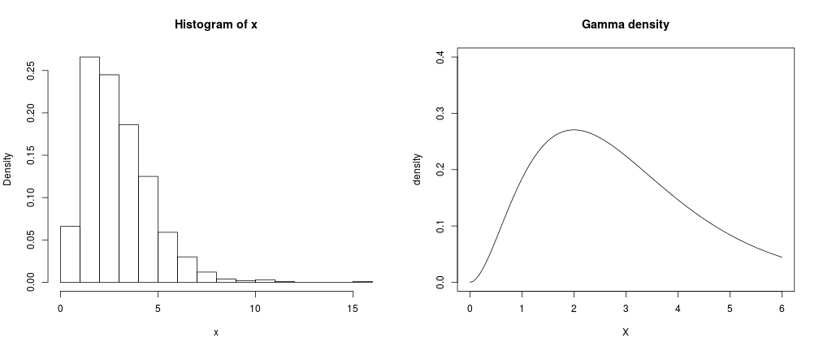

```r
## plot density histogram:
x<-rgamma(n = 1000, shape = 3)
par(mfrow=c(1,2)) # (two plots side-by-side)
hist(x,freq=F, breaks = 20)
plot(function(x) dgamma(x, shape = 3), 0, 6,
main = "Gamma density",ylim=c(0,.4),
ylab="density",xlab="X")
```

### Sampling from a gamma distribution (1)

```r
sample_size <- 100
number_of_simulations <- 1000

sample_means <- replicate(number_of_simulations, mean(rgamma(n = sample_size, shape = 3)))

mean(sample_means)
```

```
[1] 3.001549
```

```r
sd(sample_means)
```

```
[1] 0.173101
```

### Sampling from a gamma distribution (2)

Make a function to combine histogram and plot:

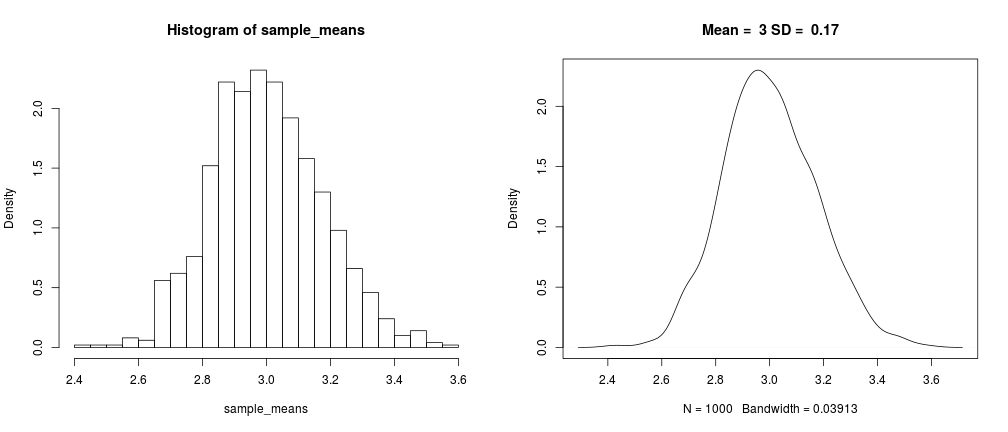

```r
make_hist_and_plot <- function(sample_means){
  par(mfrow=c(1,2)) # (two plots side-by-side)
  hist(sample_means,freq=F, breaks = 30)
  plot(density(sample_means), main = paste("Mean = ", round(mean(sample_means),2) ,
                                           "SD = ", round(sd(sample_means),2)))
} # label the plot with mean and sd
make_hist_and_plot(sample_means)
```

### Non-normal distributions: Uniform

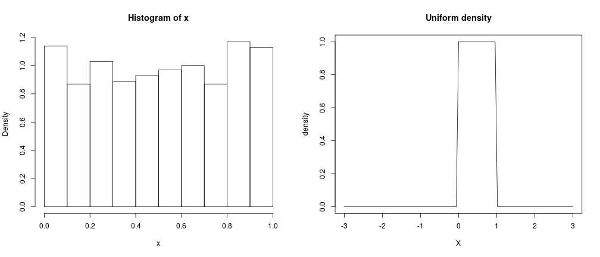

```r
## plot density histogram:
x <- runif(n = 1000)
par(mfrow=c(1,2)) # (two plots side-by-side)
hist(x,freq=F)
plot(function(x) dunif(x), -3, 3,
main = "Uniform density",ylim=c(0,1),
ylab="density",xlab="X")
```

### Sampling from a uniform distribution (1)

```r
sample_size <- 100
number_of_simulations <- 1000

sample_means <- replicate(number_of_simulations, mean(runif(n = sample_size)))

mean(sample_means)
```

```
[1] 0.5012234
```

```r
sd(sample_means)
```

```
[1] 0.02905778
```

### Sampling from a uniform distribution (2)

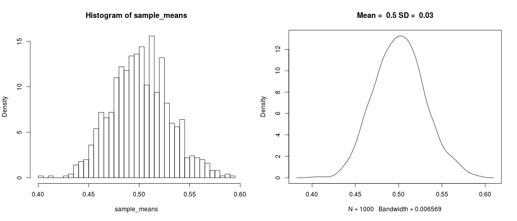

```r
make_hist_and_plot(sample_means)
```

### Non-normal distributions: Exponential

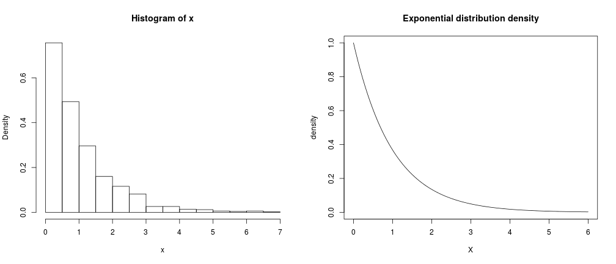

```r
## plot density histogram:
x <- rexp(n = 1000)
par(mfrow=c(1,2)) # (two plots side-by-side)
hist(x,freq=F)
plot(function(x) dexp(x), 0, 6,
main = "Exponential distribution density",ylim=c(0,1),
ylab="density",xlab="X")
```

### Sampling from an exponential distribution (1)

```r
number_of_simulations <- 100

sample_mean_from_exp<- function(number_of_samples){
  samples <- rexp(number_of_samples)
  mean(samples)
}

sample_means <- sapply(1:number_of_simulations, sample_mean_from_exp)
summary(sample_means)
```

```
   Min. 1st Qu.  Median    Mean 3rd Qu.    Max.
 0.2432  0.9001  0.9950  0.9904  1.0900  1.5360
```

### Sampling from an exponential distribution (2)

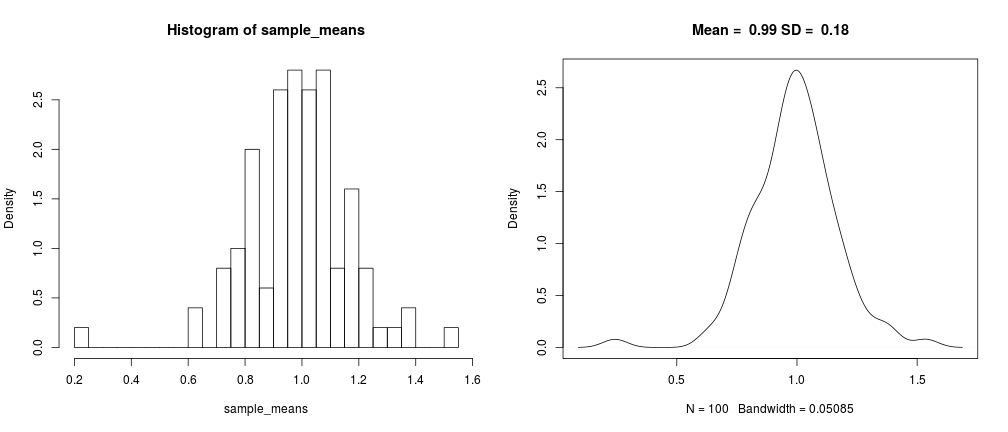

```r
make_hist_and_plot(sample_means)
```

### The sampling distribution of the mean (1)

- Notice something about the means of the samples?
  - They seem to cluster around the population mean
  - Let's play with this some more.
  - First, make a function for running the simulations so that we don't have to type all the code from the previous slides again and again
  - We're going to sample from the normal distribution again since it's easy to specify mean and sd for it.

### The sampling distribution of the mean (2)

This is our convenience function for running the simulations. Don't worry if you don't understand everything yet!

```r
run_simulation <- function(sample_size = 100,
                           number_of_simulations = 1000,
                           population_mean = 0,
                           population_sd = 1)
  {

sample_means <- replicate(number_of_simulations,
                          mean(rnorm(n = sample_size,
                                     mean = population_mean,
                                     sd = population_sd)))

make_hist_and_plot(sample_means)
}
```

### The sampling distribution of the mean (2)

It works:

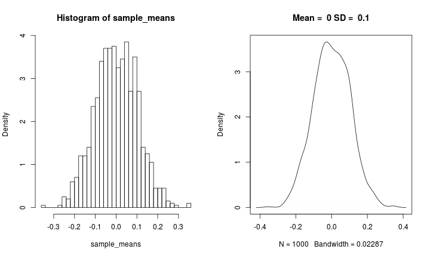

```r
run_simulation(sample_size = 100,
               number_of_simulations = 1000,
               population_mean = 0,
               population_sd = 1)
```

### The sampling distribution of the mean (3)

Now, let's try different parameters. What happens if we change the mean of the population?

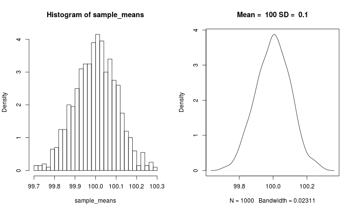

```r
run_simulation(sample_size = 100,
               number_of_simulations = 1000,
               population_mean = 100,
               population_sd = 1)
```

### The sampling distribution of the mean (3)

The sampling distribution of the mean has the same mean as the population! You can (hopefully) see how this might be useful.

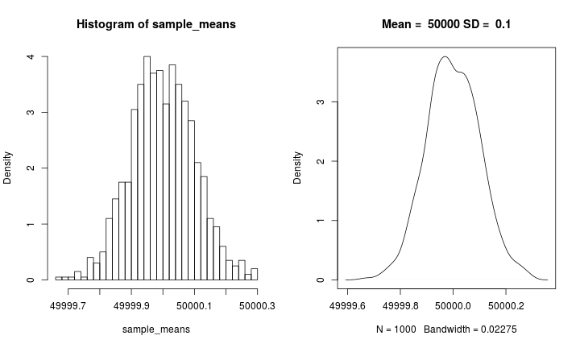

```r
run_simulation(sample_size = 100,
               number_of_simulations = 1000,
               population_mean = 50000,
               population_sd = 1)
```

### Sample mean and population mean (1)

- OK, *why* is it useful?
  - Well, usually, we don't know the population mean.
  - We have to estimate it somehow.
  - Solution: just use the sample mean as an estimator for the population mean.
  - Can this go wrong?
    - Yes, definitely.

### Sample mean and population mean (2)

- Remember the plots we just made:

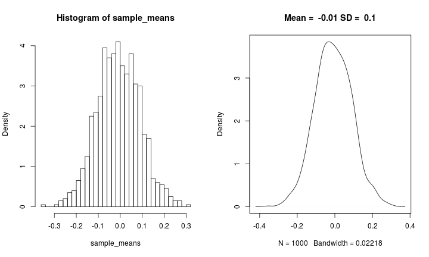

- Notice that the sample mean is not **not always** the same as the population mean (0 in this case).
  - This is due to the random nature of drawing a sample from the population.

### Sample mean and population mean (3)

- Let's try reducing the sample size

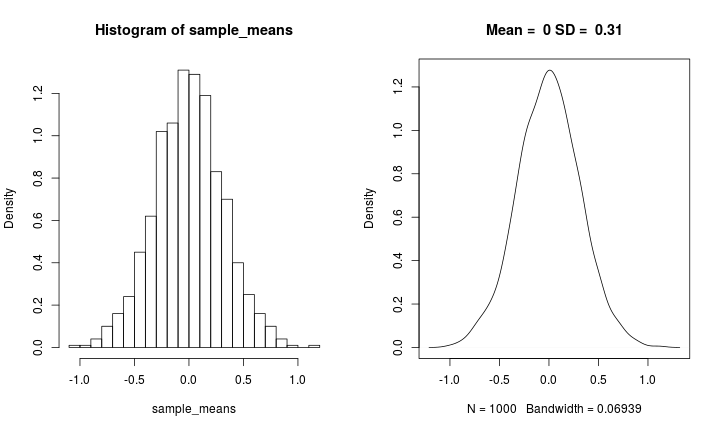

```r
run_simulation(sample_size = 10,
               number_of_simulations = 1000,
               population_mean = 0,
               population_sd = 1)
```

- Things got a bit noisier (note that the x-axis is scaled automatically)
- The sd of the distribution of the sample means went up.

### Sample mean and population mean (4)

- Let's try increasing the sample size

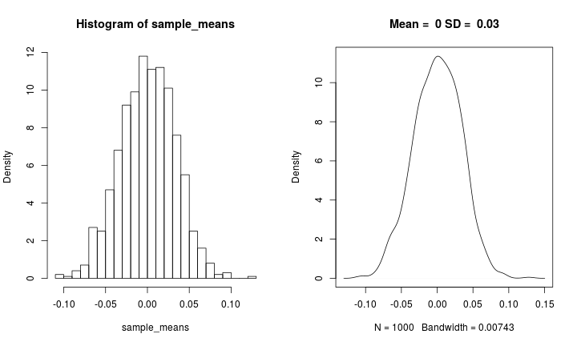

```r
run_simulation(sample_size = 1000,
               number_of_simulations = 1000,
               population_mean = 0,
               population_sd = 1)
```

- Things got a lot less noisy (note that the x-axis is scaled automatically)
- The sd of the distribution of the sample means went down.

### Standard error of the mean (SE) (1)

Population SD = 1

| Sample size | SD of the sample mean |
| --- | --- |
| 10 | .31 |
| 100 | .1 |
| 1000 | .03 |

See a pattern?

This relationship holds in general: \[ \sigma_{\bar{x}} = \frac{\sigma}{\sqrt{n}} \] where \( \sigma_{\bar{x}} \) is the standard deviation of the sample means, \( \sigma \) is the population standard deviation, and \( n \) is the sample size

### Standard error of the mean (SE) (2)

- Usually, we don't know what \( \sigma \) is, but we can still can estimate \( \sigma_{\bar{x}} \) from our sample: \[ SE_{\bar{x}} = \frac{s}{\sqrt{n}} \]

- More about that next week.